# RED WINES EXPLORATION by Anna Antonova

This report contains an analysis of a dataset of 1599 Portuguese Red wines based on their chemical characteristics and wine experts grades of these wines.

# Univariate Plots Section

```
## [1] 1599   13
```

```
## 'data.frame':    1599 obs. of  13 variables:
##  $ X                   : int  1 2 3 4 5 6 7 8 9 10 ...
##  $ fixed.acidity       : num  7.4 7.8 7.8 11.2 7.4 7.4 7.9 7.3 7.8 7.5 ...
##  $ volatile.acidity    : num  0.7 0.88 0.76 0.28 0.7 0.66 0.6 0.65 0.58 0.5 ...
##  $ citric.acid         : num  0 0 0.04 0.56 0 0 0.06 0 0.02 0.36 ...
##  $ residual.sugar      : num  1.9 2.6 2.3 1.9 1.9 1.8 1.6 1.2 2 6.1 ...
##  $ chlorides           : num  0.076 0.098 0.092 0.075 0.076 0.075 0.069 0.065 0.073 0.071 ...
##  $ free.sulfur.dioxide : num  11 25 15 17 11 13 15 15 9 17 ...
##  $ total.sulfur.dioxide: num  34 67 54 60 34 40 59 21 18 102 ...
##  $ density             : num  0.998 0.997 0.997 0.998 0.998 ...
##  $ pH                  : num  3.51 3.2 3.26 3.16 3.51 3.51 3.3 3.39 3.36 3.35 ...
##  $ sulphates           : num  0.56 0.68 0.65 0.58 0.56 0.56 0.46 0.47 0.57 0.8 ...
##  $ alcohol             : num  9.4 9.8 9.8 9.8 9.4 9.4 9.4 10 9.5 10.5 ...
##  $ quality             : int  5 5 5 6 5 5 5 7 7 5 ...
```

I will change the name of first column with wines id from ‘X’ to ‘wine.id’

```
##     wine.id       fixed.acidity   volatile.acidity  citric.acid
##  Min.   :   1.0   Min.   : 4.60   Min.   :0.1200   Min.   :0.000
##  1st Qu.: 400.5   1st Qu.: 7.10   1st Qu.:0.3900   1st Qu.:0.090
##  Median : 800.0   Median : 7.90   Median :0.5200   Median :0.260
##  Mean   : 800.0   Mean   : 8.32   Mean   :0.5278   Mean   :0.271
##  3rd Qu.:1199.5   3rd Qu.: 9.20   3rd Qu.:0.6400   3rd Qu.:0.420
##  Max.   :1599.0   Max.   :15.90   Max.   :1.5800   Max.   :1.000
##  residual.sugar     chlorides       free.sulfur.dioxide
##  Min.   : 0.900   Min.   :0.01200   Min.   : 1.00
##  1st Qu.: 1.900   1st Qu.:0.07000   1st Qu.: 7.00
##  Median : 2.200   Median :0.07900   Median :14.00
##  Mean   : 2.539   Mean   :0.08747   Mean   :15.87
##  3rd Qu.: 2.600   3rd Qu.:0.09000   3rd Qu.:21.00
##  Max.   :15.500   Max.   :0.61100   Max.   :72.00
##  total.sulfur.dioxide    density             pH          sulphates
##  Min.   :  6.00       Min.   :0.9901   Min.   :2.740   Min.   :0.3300
##  1st Qu.: 22.00       1st Qu.:0.9956   1st Qu.:3.210   1st Qu.:0.5500
##  Median : 38.00       Median :0.9968   Median :3.310   Median :0.6200
##  Mean   : 46.47       Mean   :0.9967   Mean   :3.311   Mean   :0.6581
##  3rd Qu.: 62.00       3rd Qu.:0.9978   3rd Qu.:3.400   3rd Qu.:0.7300
##  Max.   :289.00       Max.   :1.0037   Max.   :4.010   Max.   :2.0000
##     alcohol         quality
##  Min.   : 8.40   Min.   :3.000
##  1st Qu.: 9.50   1st Qu.:5.000
##  Median :10.20   Median :6.000
##  Mean   :10.42   Mean   :5.636
##  3rd Qu.:11.10   3rd Qu.:6.000
##  Max.   :14.90   Max.   :8.000
```

The dataset contains 1599 observations and 13 variables, 1 of them is numeric identifier of a wine.

Let’s start with the dependent variable “quality”

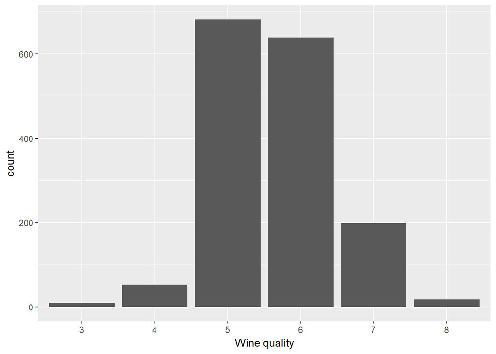

The distribution is almost normal, with a thinner left tail. The grades go from 3 to 8, and the most frequent grade is 5, the median grade being 6 and mean grade between 5 and 6.

I notice that grades are all integers between 3 and 8. So, I will convert the variable “quality” to a factor and assign the result to a new variable “quality_factor”. Now I can see how many wines got each grade.

```
##   3   4   5   6   7   8
##  10  53 681 638 199  18
```

Grades 5 and 6 have almost the same number of occurencies, then comes the grade 7 with 199 occurencies. All together, grades 5,6 and 7 represent about 95% of observations. Grades 3, 4 and 8 have an insignificant number of occurencies. It will be interesting to look closer at the wines that got these more rare grades and see what is common to them, what makes a wine stand out as an excellent or on the contrary a clearily inferior wine.

I would also like to create a new grouped quality variable: quality_grouped. It will be a factor with three levels: low quality (grades 3 and 4), average quality (grades 5 and 6) and good quality (grades 7 and 8). This grouped quality might be helpful later to better understand general trends or to explore the difference between the extremes.

There are 63 low quality wines, 1319 average wines and 217 good wines.

Now let’s figure out the distribution of this new variable.

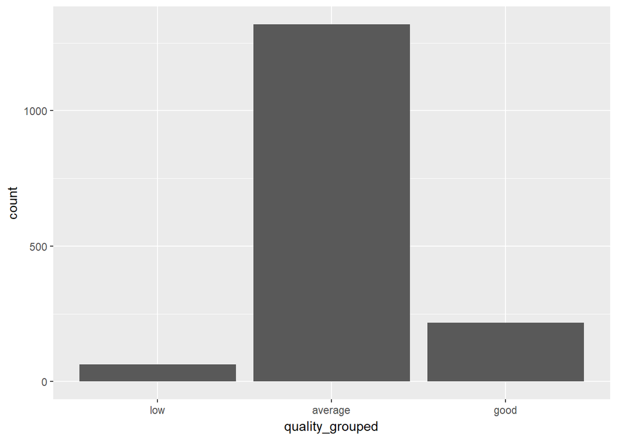

```r
ggplot(redwines, aes(quality_grouped)) + geom_bar()
```

Most wines are of average quality. There are less wines of low quality than wines of good quality.

Here is the exact count of wines per group:

```r
summary(redwines$quality_grouped)
```

```
##     low average    good
##      63    1319     217
```

Now let’s figure out the dstribution of independent or input variables.

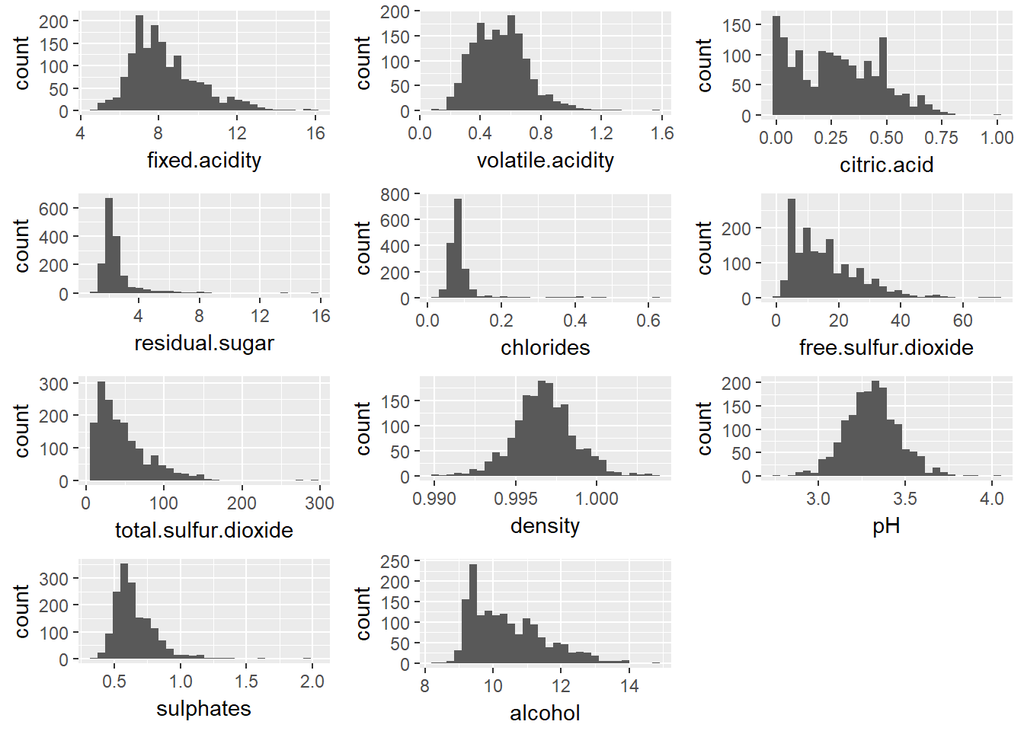

I notice that density and pH are distributed normally whereas other chemical caracteristics have eighter skewed distribution (positively for fixed acidity, total sulfur dioxide, free sufur dioxide, sulphates, alcohol, bimodal for volatile acidity). As for citric acid, the distribution does not seem to have a well defined shape, so I will take a closer look at it later. Residual sugar’s and chlorides’ distribution have a very small spread.

Now, let’s take a look at measures of acidity: fixed, volatile and citric acid and pH. Fixed acidity is a measure of such acids as tartaric, malic, citric acids while volatile acidity measures among others acetic acid, the one that is found in vinegar and excess of it alters the wine’s quality. All three types of acidity are measured as acids concentration in gram per litre. PH is negative logarithm to the base 10 of hydrogen ions concentration. That is why pH is normally distributed.

### Fixed acidity

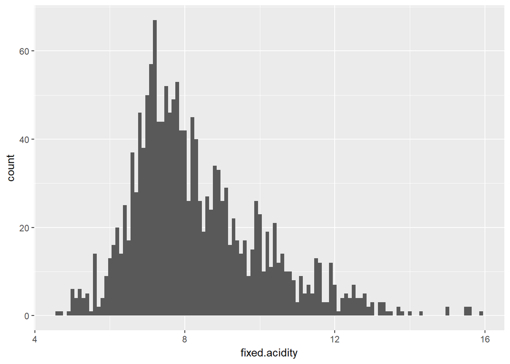

fixed acidity is positively skewed and varies between 4.6 and 15.9 g/l.

```
##    Min. 1st Qu.  Median    Mean 3rd Qu.    Max.
##    4.60    7.10    7.90    8.32    9.20   15.90
```

I decided to create a new categorical variable for measure of fixed acidity: fixed.acidity_grouped. I will group data as follows: * under 7 g/l - flat,  
* between 7 and 9 - low acidity,  
* between 9 and 11 - average acidity,  
* between 11 and 13 - higher acidity and  
* over 13 - very high acidity.

Upper limit in interval is always included and lower limit excluded. For example, low acidity > 7 and <= 9. I plan later to explore data by groups of acidity to see if there are different trends depending on acidity level.

```
##              flat       low acidity   average acidity    higher acidity
##               362               796               306               115
## very high acidity
##                20
```

Let’s look at this new variable distribution.

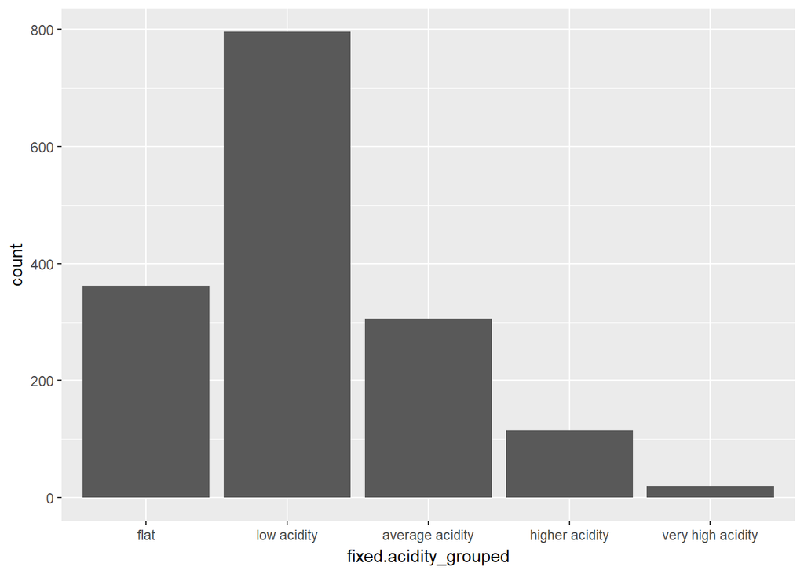

```r
ggplot(redwines, aes(fixed.acidity_grouped)) + geom_bar()
```

The distribution is positively skewed toward high acidity. Most wines have low acidity.

### Volatile acidity

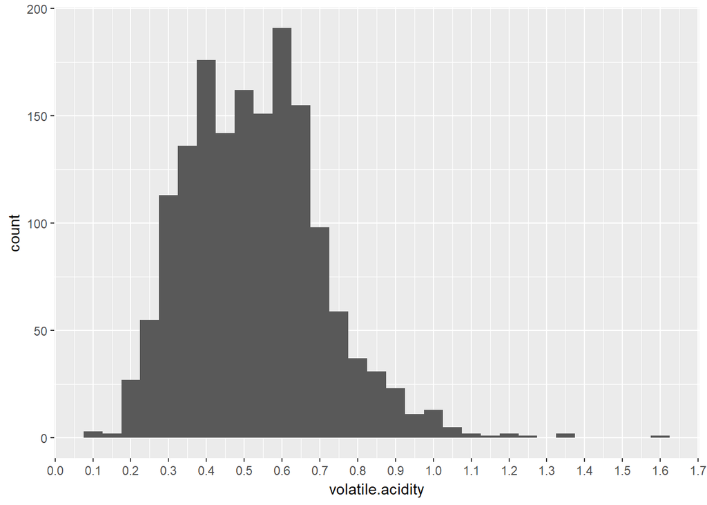

Volatile acidity is normally distributed, but is positively skewed. We can notice two modes: around 0.4 and 0.65.

### PH

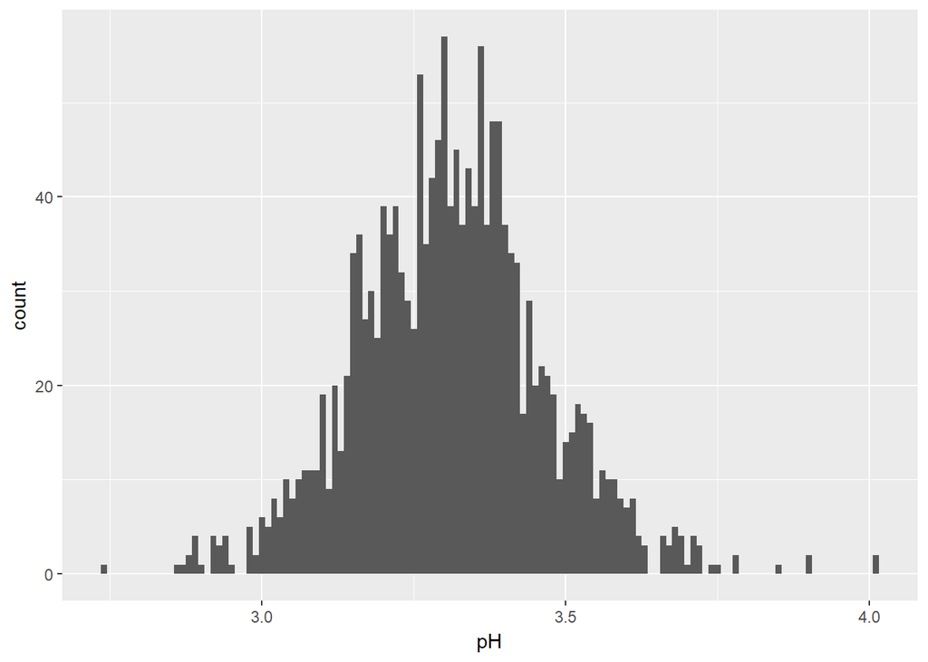

pH is normally distributed as it is calculated as a logarithm. It represents total acidity strengh.

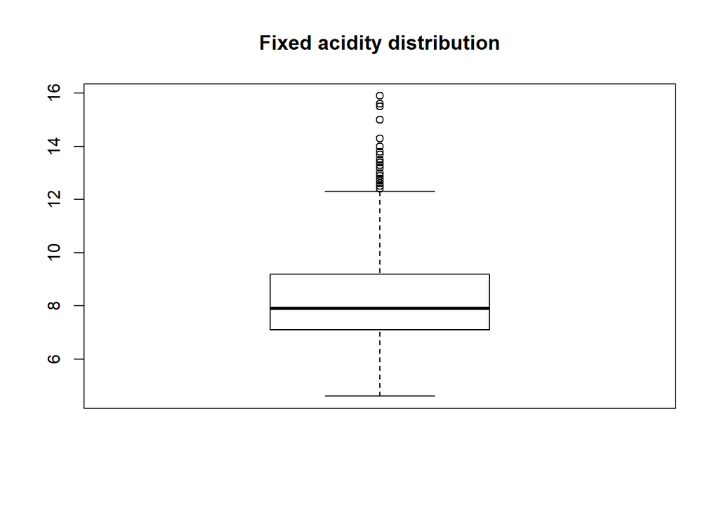

For fixed acidity there are many outliers above 12 g/l.

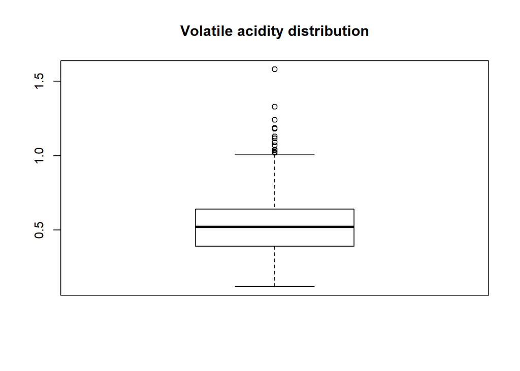

For volatile acidity there are many ouitliers above 1 g/l. Both, fixed and volatile acidity have outliers. I wonder if such a high acidity might affect the quality in a negative way.

I decided to create a new variabe with groups by volatile acidity: * under 0.2 g/l - ‘very low volatile acidity’, * between 0.2 and 0.4 - ‘low volatile acidity’, * between 0.4 and 0.8 average volatile acidity and * above 0.8 - high volatile acidity.

I would like to explore later these groups to see if there are different trends.

```
## very low volatile acidity      low volatile acidity
##                        17                       391
##  average volatile acidity     high volatile acidity
##                      1084                       107
```

Above you see number of wines per volatile acidity group.

Now let’s look at this new variable distribution.

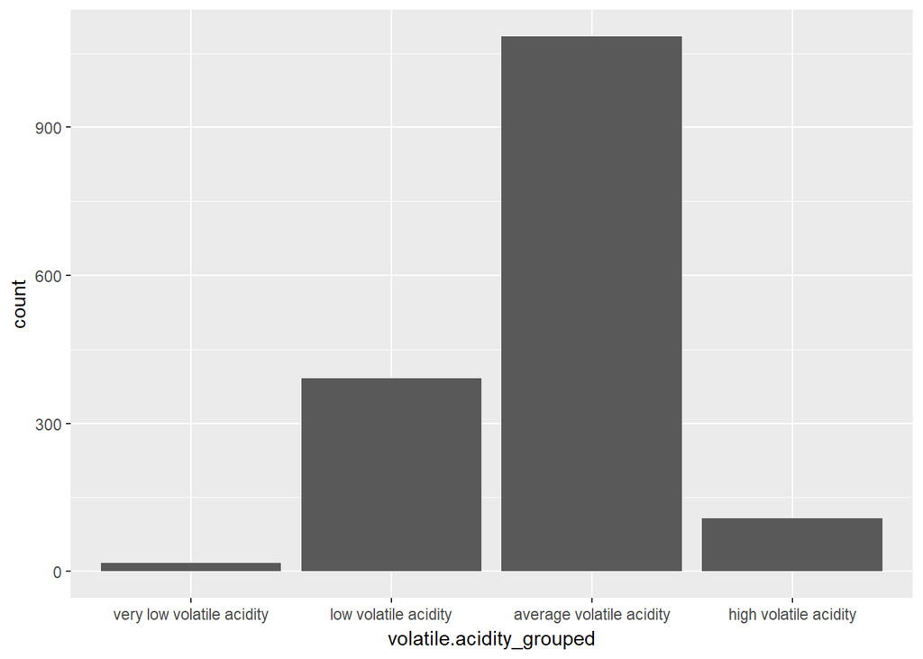

```r
ggplot(redwines, aes(volatile.acidity_grouped)) + geom_bar()
```

The distribution is negatively skewed. Most wines have average volatile acidity.

### Total acidity

What we actually taste is a total acidity, it is very difficult to distinguish which acidity we taste: volatile or fixed. That is why I will create a new variable “total.acidity” which equals the sum of volatile and fixed acidity. Let’s look at its distribution

```
##    Min. 1st Qu.  Median    Mean 3rd Qu.    Max.
##   5.120   7.680   8.445   8.847   9.740  16.285
```

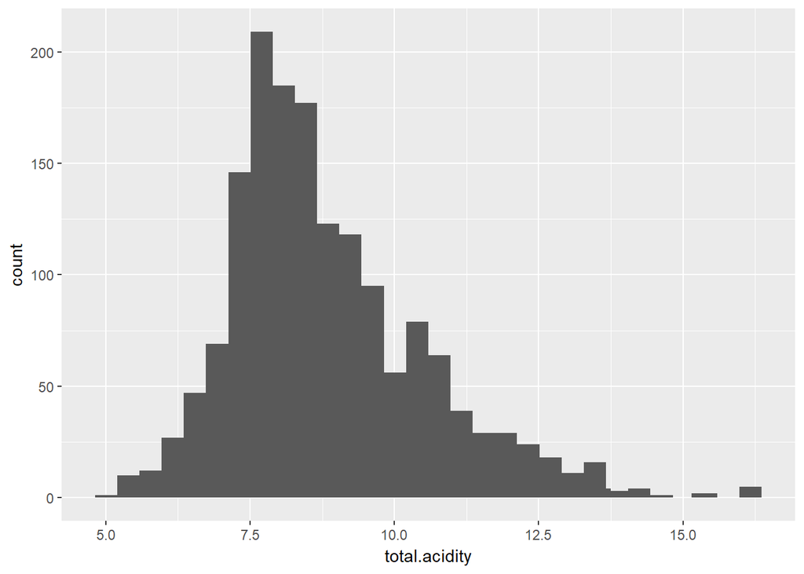

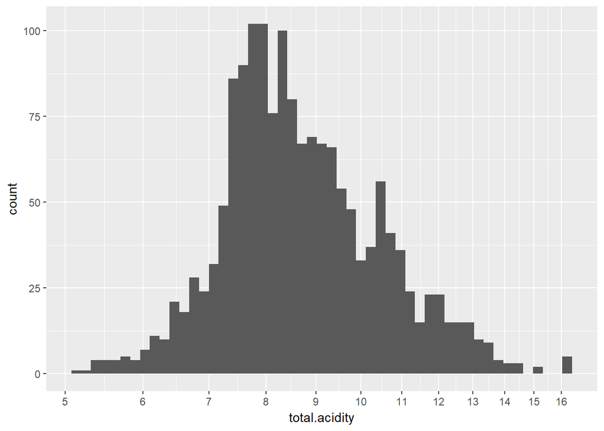

I transformed total acidity into logarthmical scale (base 10). Now the distribution loooks more normal.

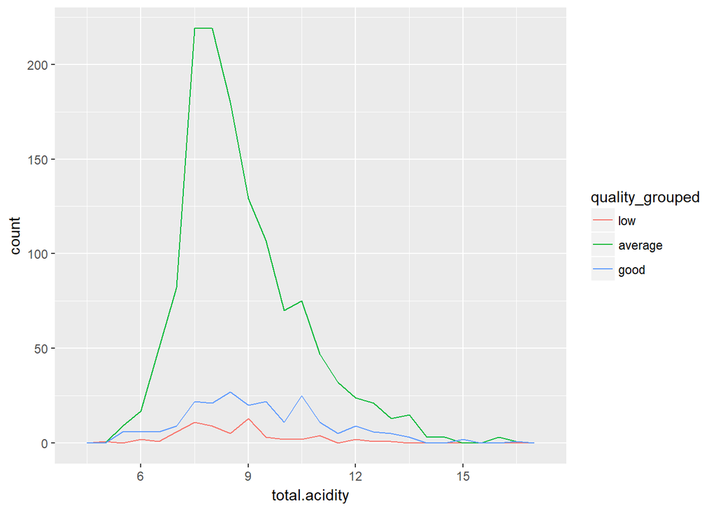

Among wines of average quality the distribution of total acidity is normal: most of these average wines have the total acidity around 8, whereas low quality and high quality wines acidity is distributed more evenly between around 5 and 12 g/l. This is most probably related to the size of the samples (very few excellent and low quality wines, so there are not enough observations to see a normal distribution). But, let’s look closer at excellent wines (grade 8).

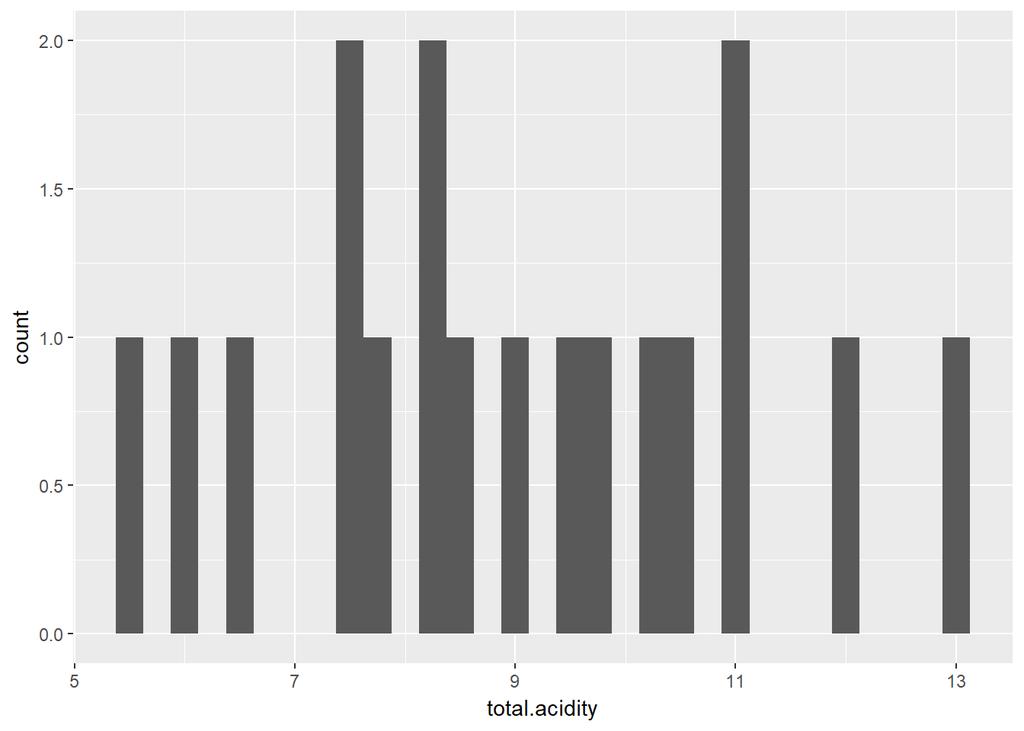

It is a uniform distribution with three modes. But again, the sample size is too small to draw conclusions.

Citric acidity is the one that gives the wine freshness and some interest. As we’ve seen earlier, the distribution shape is not well defined, so I will change the binwidth.

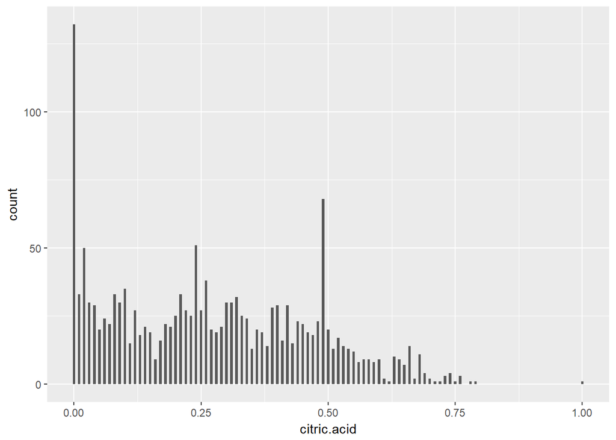

We notice that citric acid distribution is descending. This is not surprising as citric acid is present naturally at very small concentration in grapes and adding citric acid is not allowed in Europe. That is why the higher the concentration the fewer observations we have. Surprisingly, the mode is 0 g/l: there are over 125 wines without citric acid at all. I will explore it more in detail later. There is another mode at around 0.49 g/l, about 70 wines have this concentration.

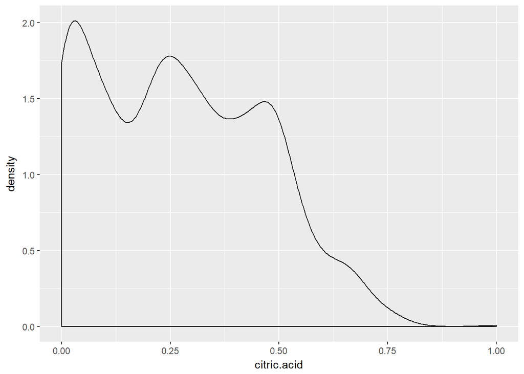

Here I notice a clear drop at around 0.5 g/l of citric acid. There a very few wines with a concentration of citric acid higher than 0.5 g/l.

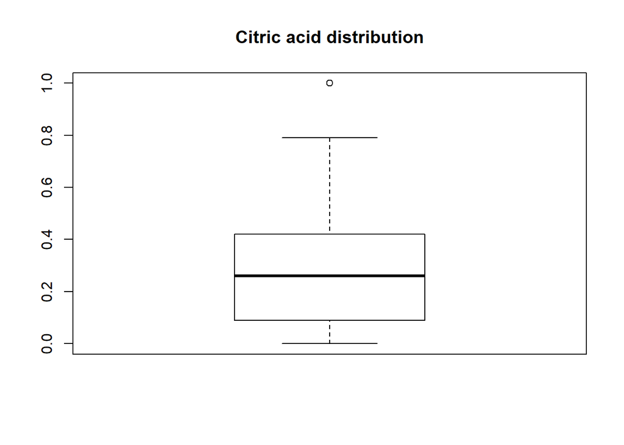

There are very few outliers for citric acid.

Minimum value for citric acid concentration is 0. Let’s verify how many obserations with 0 g/l of citric acid there are.

```
## [1] 132  18
```

There are 132 wines without citric acid.

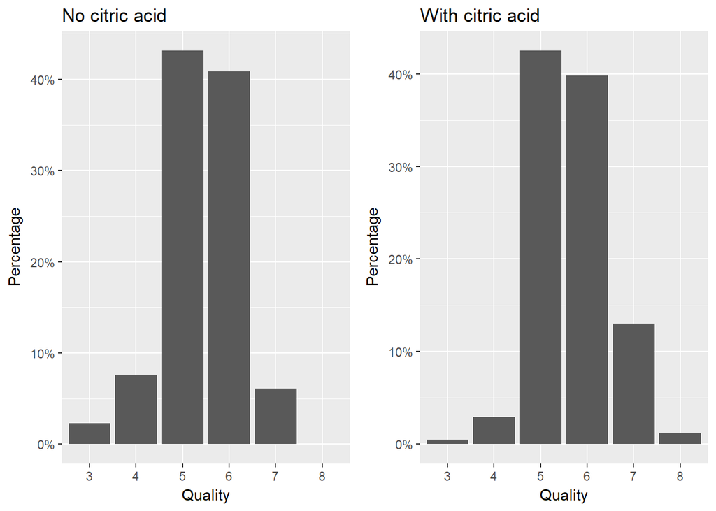

Wines without citric acid at all did not get any 8 grade and have lesser percentage of grade 7, they also have a higher percentage of grades 3 and 4. Is citrtic acid presence necessary to make a wine outstanding? Does lack of citric acid contribute to the fact that a wine is perceived as a lower quality wine and under wich conditions? Can the lack of citric acid be compensated and how (what differs 7 grade wines with and without citric acid)?

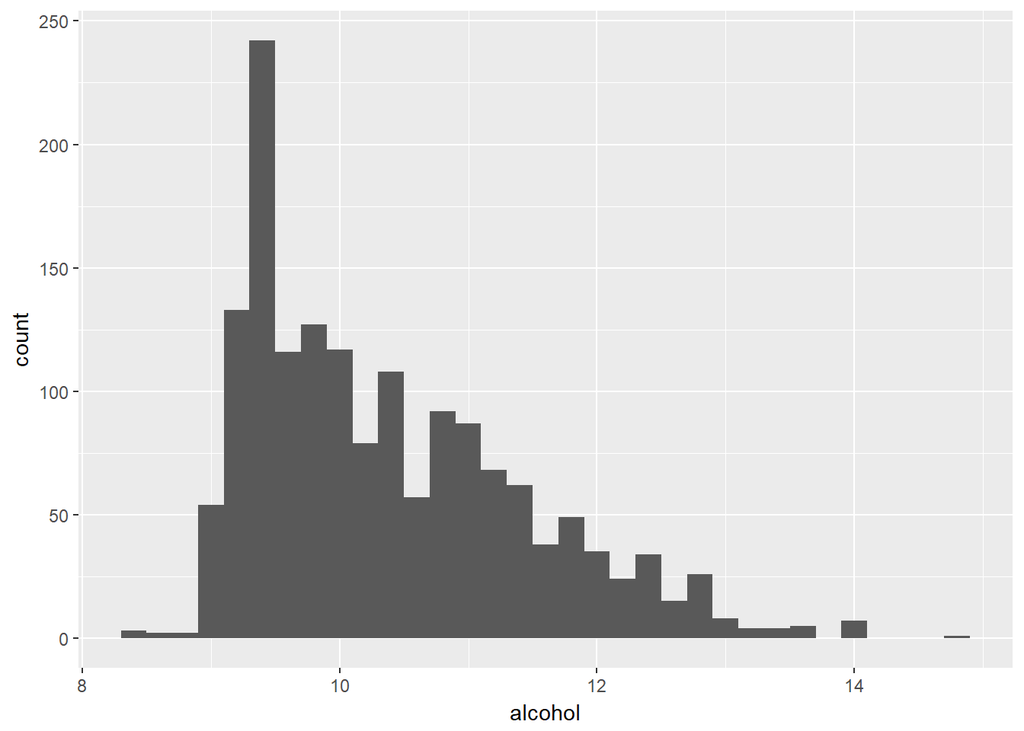

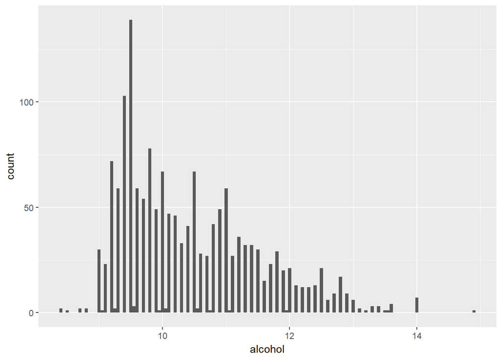

Let’s check alcohol data for outliers

```
##  75%
## 13.5
```

Wines with more than 13.5% alcohol content are outliers. 75% here indicated that the value has been calculated from the 75% quantile.

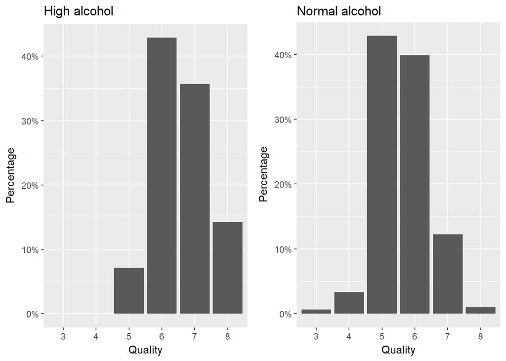

Wines with high alcohol content in this sample did not obtain low grades like 3 or 4 at all. They got relatively more 8 grades than wines with normal alcohol content. Does higher alcohol content enhance wine taste? Of course, the size of high alcohol content’ wines subset is too small which probably is the reason for absence of certain grades. Nevertheless, I will keep it in mind and explore the effect of alcohol content on wine quality.

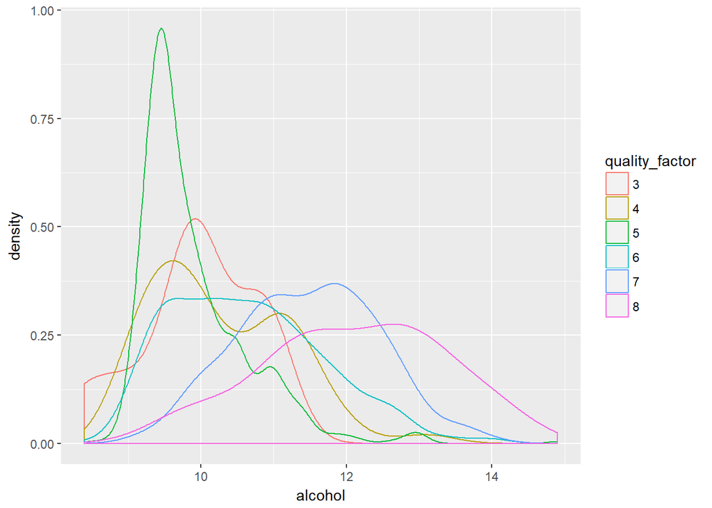

We notice that as quality increases the distributions shift to the right. This means that the highr the alcohol content the higher the probability that this wine willl get a higher grade (7 or 8). We don’t see the same pattern for lower grades: 3, 4, 5, 6. Let’s look at the same distribution but by grouped quality (low, average and good).

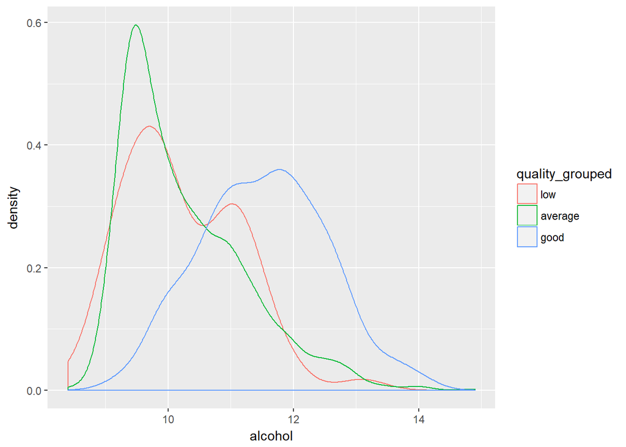

The probability here is measured by the surface of the area below the curve. Here the trend is clear: at very low alcohol content (below 9%) the probability that the wine will be of low quality is higher than to be of average quality, and almost 0 probability that this wine will be of good quality. This pattern is reversed at higher alcohol content (above 12%). For example, the wine with alcohol content above 12% has very high probabilty of being good, low probability of being average and very low - of being poor.

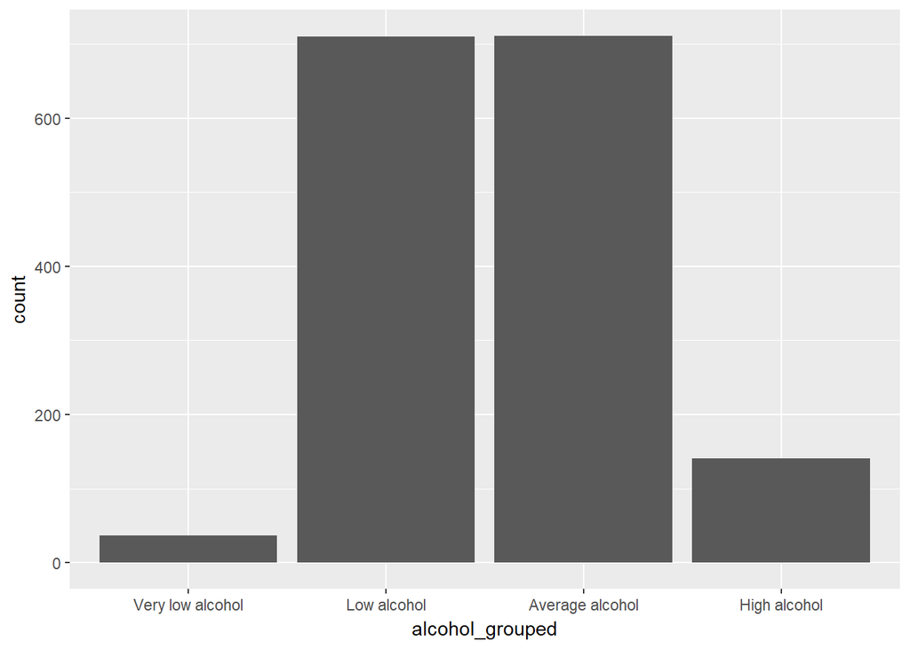

```r
ggplot(redwines, aes(alcohol_grouped)) + geom_bar()
```

Here is the exact count of wines per group.

```r
summary(redwines$alcohol_grouped)
```

```
## Very low alcohol      Low alcohol  Average alcohol     High alcohol
##               37              710              711              141
```

The distribution look normal with two equal modes: around 700 wines with low alcohol, and 700 wines with average alcohol.

Now let’s look at sulphur dioxide (SO2), total sulfur dioxide and sulphates

```
## [1] "free SO2"
```

```
##    Min. 1st Qu.  Median    Mean 3rd Qu.    Max.
##    1.00    7.00   14.00   15.87   21.00   72.00
```

```
## [1] "total SO2"
```

```
##    Min. 1st Qu.  Median    Mean 3rd Qu.    Max.
##    6.00   22.00   38.00   46.47   62.00  289.00
```

```
## [1] "potassium sulphates"
```

```
##    Min. 1st Qu.  Median    Mean 3rd Qu.    Max.
##  0.3300  0.5500  0.6200  0.6581  0.7300  2.0000
```

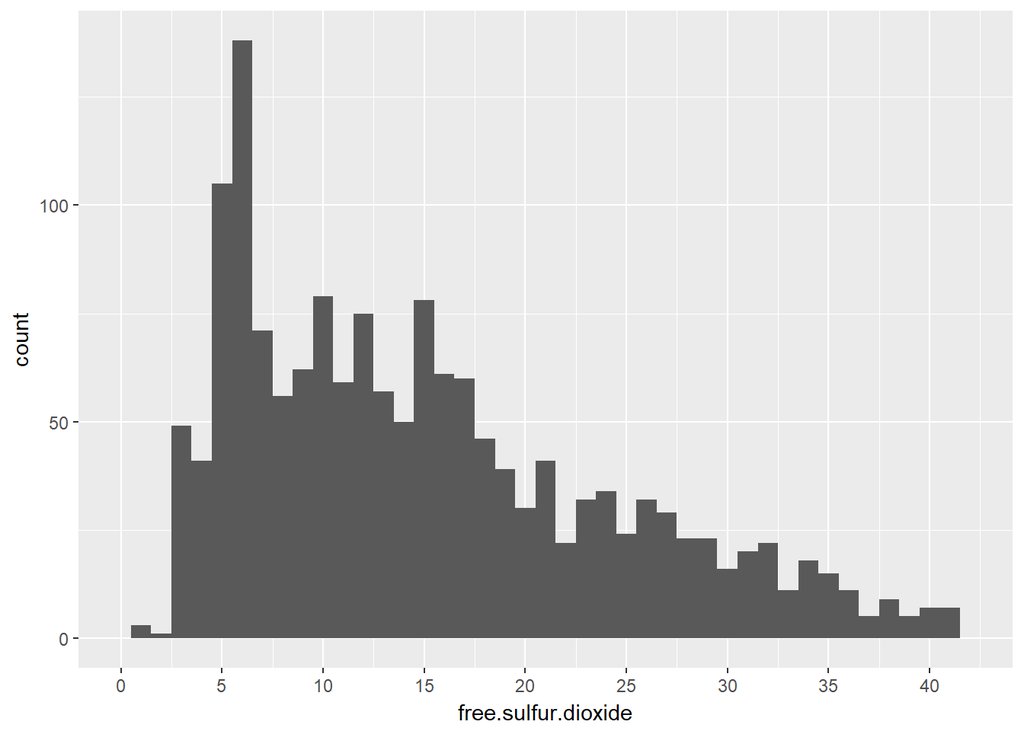

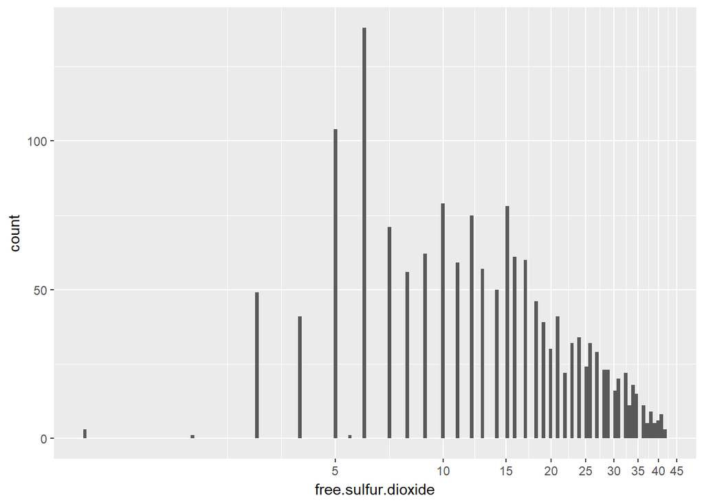

Free sulfur dioxide is necessary to a wine to prevent oxidation and protect wine from bacteria. The distribution is positively skewed. After I transformed the x axis to a log10 axis I can see a less skewed distribution with mode around 6 mg/l. I notice a clear descending trend after concentration of about 15 mg/l.

Potassium sulphates are measured in g/l, their concentration is much higher than the concentration of sulfur dioxide.

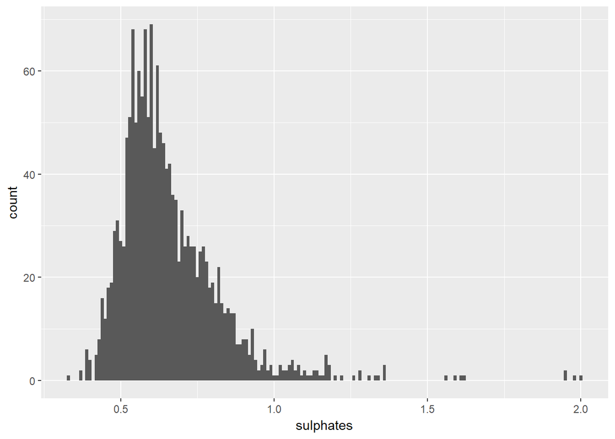

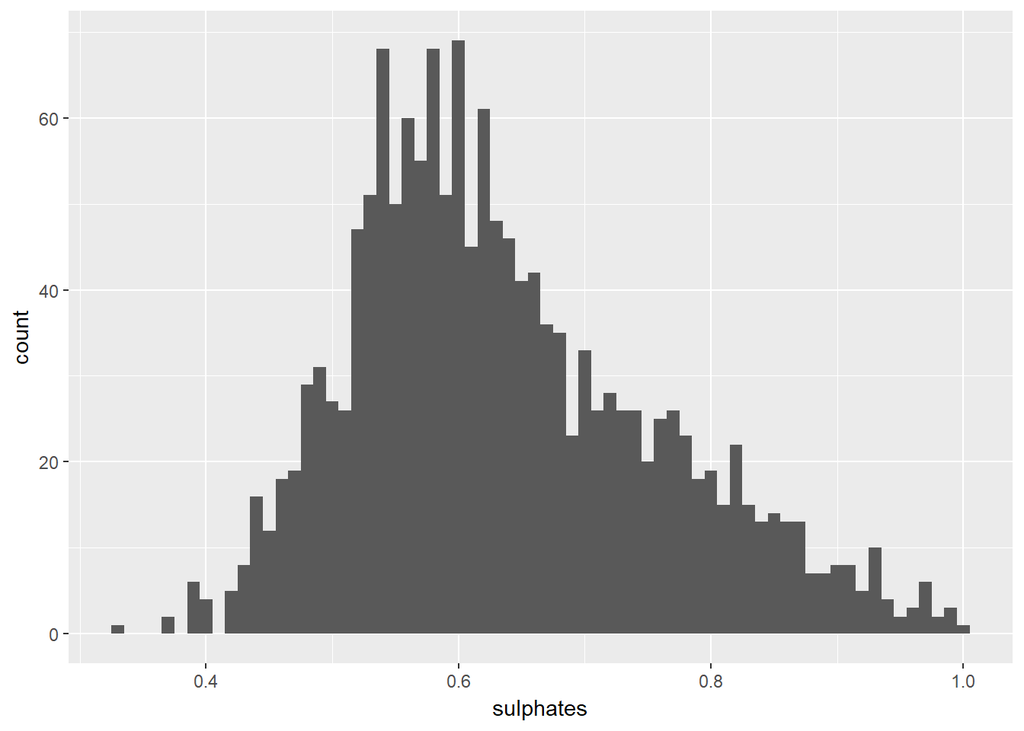

I removed the outliers ( > 1 g/l ) to have a better idea of the distribution of the main data.

The distribution looks close to normal, slightly positively skewed.

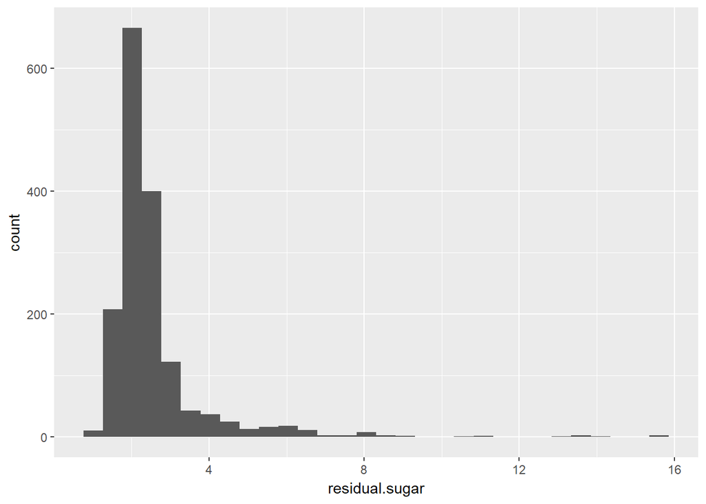

There are many outliers. I would like to consider separately subset without outilers. I will first determine the value above which data will be considered outliers. I will use 1.5 * IQR.

```
##  75%
## 3.65
```

Above 3.65 g/l of residual sugar the wine is considered outlier. 75% indicates that it was calculated from 75% quantile

I will plot residual sugar distribution for subset without outliers (sugar <= 3.65 g/l)

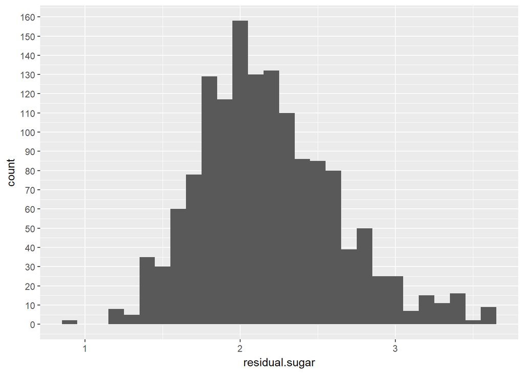

There are very few (about 2) wines with sugar less than 1 g/l. Most wines have sugar at around 2 g/l. The distrbution without outliers looks normal.

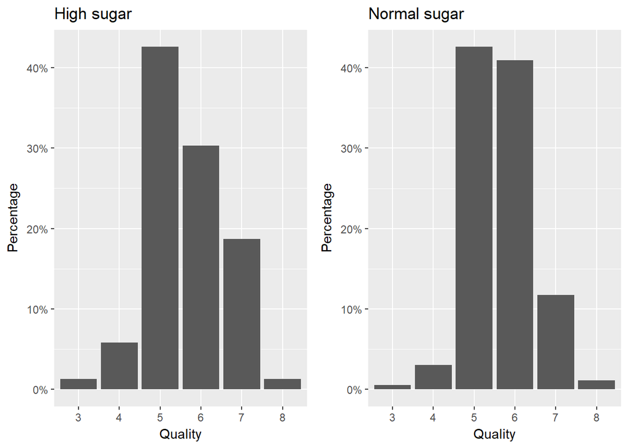